# Hypothesis Tests

For all of variables of interest, we compute substantively meaningful quantities of interest and their confidence intervals rather than relying directly on a table of model coefficients. The quantities of interest (QIs) are as follows:

- **First-Difference (FD).** This is just the probability of answering correctly when the variable of interest takes on a high value minus the probability of answering correctly with the variable of interest takes on a low value. In the case of education, these values are 6 (a college degree) and 3 (a high school diploma), respectively. This does not account for ceiling and floor effects.
- **Odds-Ratio (OR).** This QI makes an explicit attempts to control for ceiling and floor effects, because odds-ratios are constant regardless of the other variables and their coefficients. This is equivalent to simply inspecting the coefficients, although the change we consider is more substantively interesting.
- **Risk-Ratio (RR).** This QI tells us how much more likely those with high values of the explanatory variable are to answer correctly than those that have low values of the explanatory variable. It treats a change from 0.01 to 0.02 and 0.25 to 0.50 equals effect sizes. In in both cases, the risk-ratio is 2, meaning that the change in the explanatory variable doubles the chance of answering correctly. Note that this partial addresses concerns about floor effects, but worsens any concerns about ceiling effects. Note that a risk-ration of 1.5 means that the chance of answering correctly increases by 50% when the explanatory variable is high rather than low.

## Education

### Quadrant Plot

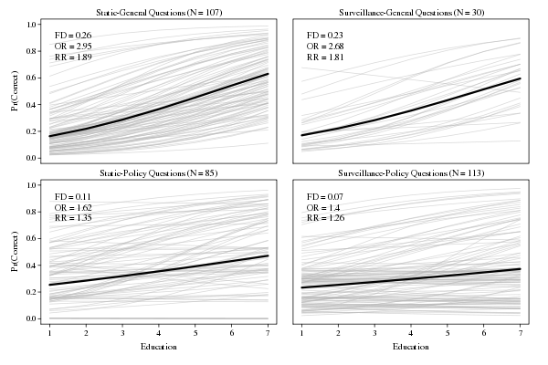

### p-Values for Differences Between Effects

The table below provides p-values for the research hypothesis that the variable in the row has a larger effect than the variable in the column. The null hypothesis, then, is that the variable in the column has the same, or a smaller, effect than the variable in the row.

Using **first-differences** to judge effect size:

|  | Surveillance-General | Static-General | Surveillance-Policy | Static-Policy |
| --- | --- | --- | --- | --- |
| **Surveillance-General** |  | 1.00 | 0.89 | 0.90 |
| **Static-General** | 0.00 |  | 0.01 | 0.01 |
| **Surveillance-Policy** | 0.11 | 0.99 |  | 0.50 |
| **Static-Policy** | 0.10 | 0.99 | 0.50 |  |

Using **odds-ratios** to judge effect size:

|  | Surveillance-General | Static-General | Surveillance-Policy | Static-Policy |
| --- | --- | --- | --- | --- |
| **Surveillance-General** |  | 1.00 | 0.87 | 0.86 |
| **Static-General** | 0.00 |  | 0.02 | 0.01 |
| **Surveillance-Policy** | 0.13 | 0.98 |  | 0.49 |
| **Static-Policy** | 0.14 | 0.99 | 0.51 |  |

Using **risk-ratios** to judge effect size:

|  | Surveillance-General | Static-General | Surveillance-Policy | Static-Policy |
| --- | --- | --- | --- | --- |
| **Surveillance-General** |  | 0.98 | 0.85 | 0.84 |
| **Static-General** | 0.02 |  | 0.04 | 0.02 |
| **Surveillance-Policy** | 0.15 | 0.96 |  | 0.50 |
| **Static-Policy** | 0.16 | 0.98 | 0.50 |  |

### Second-Differences and Confidence Intervals

The tables below provide the 90% confidence intervals for the second-differences (the difference between the first differences). These are especially for arguing that the differences are not meaningful by arguing that the second-difference only contains negligible values (see Rainey 2014). These second-differences are the effect (first-difference) of the variable in the row minus the effect (first-difference) of the variable in the column.

|  | Surveillance-General | Static-General | Surveillance-Policy | Static-Policy |
| --- | --- | --- | --- | --- |
| **Surveillance-General** |  | -0.54 [-0.81, -0.28] | -0.21 [-0.53, 0.07] | -0.21 [-0.49, 0.09] |
| **Static-General** | 0.54 [0.28, 0.81] |  | 0.33 [0.08, 0.54] | 0.33 [0.12, 0.52] |
| **Surveillance-Policy** | 0.21 [-0.07, 0.53] | -0.33 [-0.54, -0.08] |  | 0.00 [-0.23, 0.26] |
| **Static-Policy** | 0.21 [-0.09, 0.49] | -0.33 [-0.52, -0.12] | -0.00 [-0.26, 0.23] |  |

## Media

### Quadrant Plot

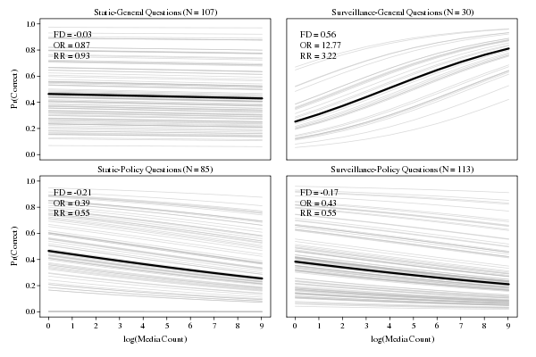

### Differences Between Effects

The table below provides p-values for the research hypothesis that the variable in the row has a larger effect than the variable in the column. The null hypothesis, then, is that the variable in the column has the same, or a smaller, effect than the variable in the row.

Using **first-differences** to judge effect size:

|  | Surveillance-General | Static-General | Surveillance-Policy | Static-Policy |
| --- | --- | --- | --- | --- |
| **Surveillance-General** |  | 0.00 | 0.02 | 0.00 |
| **Static-General** | 1.00 |  | 0.64 | 0.47 |
| **Surveillance-Policy** | 0.98 | 0.36 |  | 0.34 |
| **Static-Policy** | 1.00 | 0.53 | 0.66 |  |

Using **odds-ratios** to judge effect size:

|  | Surveillance-General | Static-General | Surveillance-Policy | Static-Policy |
| --- | --- | --- | --- | --- |
| **Surveillance-General** |  | 0.00 | 0.01 | 0.00 |
| **Static-General** | 1.00 |  | 0.64 | 0.44 |
| **Surveillance-Policy** | 0.99 | 0.36 |  | 0.33 |
| **Static-Policy** | 1.00 | 0.56 | 0.67 |  |

Using **risk-ratios** to judge effect size:

|  | Surveillance-General | Static-General | Surveillance-Policy | Static-Policy |
| --- | --- | --- | --- | --- |
| **Surveillance-General** |  | 0.00 | 0.01 | 0.00 |
| **Static-General** | 1.00 |  | 0.64 | 0.43 |
| **Surveillance-Policy** | 0.99 | 0.36 |  | 0.32 |
| **Static-Policy** | 1.00 | 0.57 | 0.68 |  |

### Second-Differences and Confidence Intervals

The tables below provide the 90% confidence intervals for the second-differences (the difference between the first differences). These are especially for arguing that the differences are not meaningful by arguing that the second-difference only contains negligible values (see Rainey 2014). These second-differences are the effect (first-difference) of the variable in the row minus the effect (first-difference) of the variable in the column.

|  | Surveillance-General | Static-General | Surveillance-Policy | Static-Policy |
| --- | --- | --- | --- | --- |
| **Surveillance-General** |  | 0.86 [0.44, 1.21] | 0.75 [0.23, 1.21] | 0.88 [0.38, 1.26] |
| **Static-General** | -0.86 [-1.21, -0.44] |  | -0.11 [-0.60, 0.37] | 0.02 [-0.45, 0.43] |
| **Surveillance-Policy** | -0.75 [-1.21, -0.23] | 0.11 [-0.37, 0.60] |  | 0.15 [-0.39, 0.63] |
| **Static-Policy** | -0.88 [-1.26, -0.38] | -0.02 [-0.43, 0.45] | -0.15 [-0.63, 0.39] |  |

## Gender

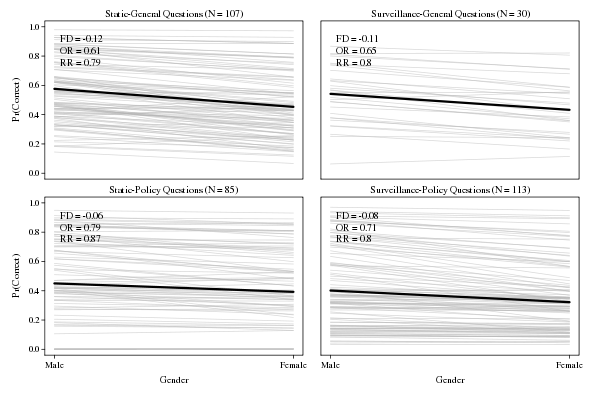

### Effect Sizes and Confidence Intervals for Non-Gendered Questions

Here are the effects of gender for non-gendered questions:

- Surveillance-General
  - FD: 0.26 - 0.27 = -0.01 [-0.25, 0.27], p = 0.48
  - OR: 0.95 [0.25, 3.53], p = 0.48
  - RR: 0.96 [0.35, 2.36], p = 0.48
  - Static-General
  - FD: 0.45 - 0.54 = -0.08 [-0.25, 0.10], p = 0.24
  - OR: 0.71 [0.34, 1.54], p = 0.24
  - RR: 0.85 [0.55, 1.25], p = 0.24
- Surveillance-Policy
  - FD: 0.23 - 0.41 = -0.16 [-0.34, 0.01], p = 0.06
  - OR: 0.45 [0.20, 1.05], p = 0.06
  - RR: 0.59 [0.33, 1.04], p = 0.06
  - Static-Policy
  - FD: 0.43 - 0.40 = 0.03 [-0.15, 0.20], p = 0.60
  - OR: 1.14 [0.52, 2.30], p = 0.60
  - RR: 1.07 [0.67, 1.62], p = 0.60

### Differences Between Effects

The table below provides p-values for the research hypothesis that the variable in the row has a larger effect than the variable in the column. The null hypothesis, then, is that the variable in the column has the same, or a smaller, effect than the variable in the row.

Using **first-differences** to judge effect size:

|  | Surveillance-General | Static-General | Surveillance-Policy | Static-Policy |
| --- | --- | --- | --- | --- |
| **Surveillance-General** |  | 0.33 | 0.18 | 0.56 |
| **Static-General** | 0.67 |  | 0.26 | 0.79 |
| **Surveillance-Policy** | 0.82 | 0.74 |  | 0.93 |
| **Static-Policy** | 0.44 | 0.21 | 0.07 |  |

Using **odds-ratios** to judge effect size:

|  | Surveillance-General | Static-General | Surveillance-Policy | Static-Policy |
| --- | --- | --- | --- | --- |
| **Surveillance-General** |  | 0.37 | 0.20 | 0.56 |
| **Static-General** | 0.63 |  | 0.21 | 0.79 |
| **Surveillance-Policy** | 0.80 | 0.79 |  | 0.94 |
| **Static-Policy** | 0.44 | 0.21 | 0.06 |  |

Using **risk-ratios** to judge effect size:

|  | Surveillance-General | Static-General | Surveillance-Policy | Static-Policy |
| --- | --- | --- | --- | --- |
| **Surveillance-General** |  | 0.40 | 0.23 | 0.56 |
| **Static-General** | 0.60 |  | 0.16 | 0.78 |
| **Surveillance-Policy** | 0.77 | 0.84 |  | 0.94 |
| **Static-Policy** | 0.44 | 0.22 | 0.06 |  |

## Gender Gap Reversal

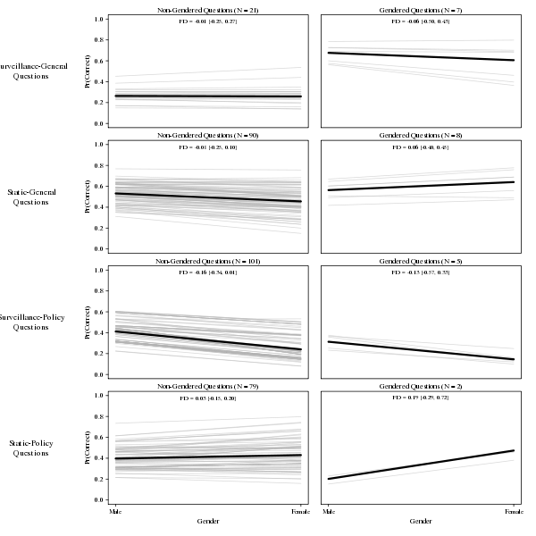

Hypothesis: The gender gap should be smaller for gendered questions than for non-gendered general questions across all four quadrants. (Note: The p-values below test the null hypothesis that the gender gap is larger among non-gendered questions. We are expecting non-statistical signficant results. I suggest using CIs in this situation)

- Surveillance-General
  - Using FDs: 0.08 [-0.49, 0.53], *p = 0.58*
  - Using ORs: 0.22 [-6.86, 2.46], *p = 0.59*
  - Using ORs: 0.08 [-2.00, 1.39], *p = 0.55*
- Static-General
  - Using FDs: -0.14 [-0.55, 0.32], *p = 0.30*
  - Using ORs: -0.64 [-9.76, 0.84], *p = 0.31*
  - Using ORs: -0.25 [-1.81, 0.50], *p = 0.30*
- Surveillance-Policy
  - Using FDs: -0.04 [-0.50, 0.40], *p = 0.45*
  - Using ORs: 0.05 [-6.08, 0.66], *p = 0.53*
  - Using ORs: 0.07 [-2.74, 0.68], *p = 0.53*
- Static-Policy
  - Using FDs: -0.17 [-0.71, 0.34], *p = 0.28*
  - Using ORs: -2.21 [-78.31, 1.05], *p = 0.26*
  - Using ORs: -0.96 [-15.45, 0.73], *p = 0.27*

## Model Estimates

Here are the coefficients for the main model and the two robustness checks. In the papers, I recommend reporting all the coefficients. We might consider combining c.surveillance and c.surveillance.alt (and its products) into the same rows to save a little space. From the model summary statistics, I recommend reporting the number of observations, the number of questions, the number of respondents, and the BIC (though this only allow us to compare the fit of the models with the same sample size, so we might want to make a note that the BIC from the “drop apolitical model” cannot be compared to the other two). Jason might have a preference that we include information about the respondent-level or question-level variances, but I am indifferent between including and excluding those.

|  | **Main** | **Cutoff = 42 Days** | **Drop Apolitical Q’s** |
| --- | --- | --- | --- |
| (Intercept) | -0.22 (0.18) | -0.17 (0.19) | -0.21 (0.21) |
| c.eduimp | 1.06 (0.38)** | 1.47 (0.41)*** | 1.37 (0.44)** |
| c.policyspecific | -0.19 (0.34) | -0.35 (0.38) | -0.44 (0.41) |
| c.surveillance | -0.44 (0.30) |  | -0.38 (0.49) |
| c.fem | -0.17 (0.33) | -0.35 (0.36) | -0.31 (0.36) |
| c.gendered | 0.04 (0.52) | -0.28 (0.55) | 0.09 (0.54) |
| c.lnct | 0.25 (0.34) | 0.19 (0.34) | 0.11 (0.37) |
| c.incimp | 0.11 (0.33) | 0.07 (0.32) | -0.04 (0.36) |
| c.ageimp | 0.27 (0.33) | 0.28 (0.32) | 0.31 (0.35) |
| c.blk | 0.48 (0.49) | 0.47 (0.48) | 0.66 (0.53) |
| c.dem | -0.17 (0.40) | -0.16 (0.38) | -0.14 (0.42) |
| c.rep | -0.03 (0.36) | -0.08 (0.35) | 0.09 (0.39) |
| c.oe | 0.48 (0.59) | 0.47 (0.63) | 0.07 (0.66) |
| c.randomizedanswerchoices | 0.65 (0.27)* | 0.55 (0.27)* | 0.32 (0.31) |
| c.answerchoices | 0.11 (0.32) | 0.15 (0.39) | 0.05 (0.35) |
| c.dk.justtellme | 0.20 (0.34) | 0.09 (0.33) | 0.65 (0.43) |
| c.noct | 0.12 (0.45) | 0.01 (0.44) | 0.20 (0.51) |
| c.apolitical | 0.41 (0.49) | 0.68 (0.47) |  |
| c.eduimp:c.policyspecific | -0.59 (0.53) | -1.46 (0.70)* | -1.28 (0.69) |
| c.eduimp:c.surveillance | -0.94 (0.54) |  | -0.71 (0.69) |
| c.policyspecific:c.surveillance | 0.24 (0.61) |  | 1.29 (0.99) |
| c.fem:c.gendered | 0.49 (0.85) | 0.50 (0.88) | 0.53 (0.88) |
| c.policyspecific:c.fem | 0.01 (0.47) | 0.35 (0.59) | 0.08 (0.54) |
| c.policyspecific:c.gendered | -1.35 (0.97) | -0.92 (1.02) | -1.21 (1.01) |
| c.surveillance:c.fem | -0.56 (0.49) |  | -0.91 (0.57) |
| c.surveillance:c.gendered | 0.43 (1.00) |  | 0.27 (1.04) |
| c.policyspecific:c.lnct | -1.02 (0.60) | -1.07 (0.64) | -0.79 (0.69) |
| c.surveillance:c.lnct | 1.25 (0.61)* |  |  |
| c.eduimp:c.policyspecific:c.surveillance | 2.60 (1.08)* |  | 1.85 (1.52) |
| c.policyspecific:c.fem:c.gendered | 0.34 (1.60) | 0.40 (1.64) | 0.09 (1.65) |
| c.surveillance:c.fem:c.gendered | -1.17 (1.66) |  | -0.94 (1.72) |
| c.policyspecific:c.surveillance:c.fem | -1.24 (1.01) |  | -0.77 (1.20) |
| c.policyspecific:c.surveillance:c.gendered | -1.29 (1.88) |  | -0.67 (1.98) |
| c.policyspecific:c.surveillance:c.lnct | -2.43 (1.26) |  |  |
| c.policyspecific:c.surveillance:c.fem:c.gendered | -0.42 (3.13) |  | -1.69 (3.30) |
| c.surveillance.alt |  | -0.16 (0.42) | 0.04 (0.58) |
| c.eduimp:c.surveillance.alt |  | 0.73 (0.89) |  |
| c.policyspecific:c.surveillance.alt |  | -0.76 (0.95) | -1.93 (1.26) |
| c.surveillance.alt:c.fem |  | -1.11 (0.75) |  |
| c.surveillance.alt:c.gendered |  | -0.12 (1.11) |  |
| c.surveillance.alt:c.lnct |  | 1.49 (0.77) |  |
| c.eduimp:c.policyspecific:c.surveillance.alt |  | -1.47 (2.06) |  |
| c.surveillance.alt:c.fem:c.gendered |  | -0.76 (1.79) |  |
| c.policyspecific:c.surveillance.alt:c.fem |  | 0.27 (1.76) |  |
| c.policyspecific:c.surveillance.alt:c.gendered |  | 1.92 (2.28) |  |
| c.policyspecific:c.surveillance.alt:c.lnct |  | -2.85 (1.71) |  |
| c.policyspecific:c.surveillance.alt:c.fem:c.gendered |  | -0.92 (3.58) |  |
| c.lnct:c.surveillance.alt |  |  | 1.45 (0.79) |
| c.policyspecific:c.lnct:c.surveillance.alt |  |  | -2.22 (1.75) |
| AIC | 1147.50 | 1159.02 | 1044.40 |
| BIC | 1350.22 | 1361.73 | 1247.52 |
| Log Likelihood | -531.75 | -537.51 | -479.20 |
| Deviance | 1063.50 | 1075.02 | 958.40 |
| Num. obs. | 922 | 922 | 832 |
| Num. groups: Q | 313 | 313 | 282 |
| Num. groups: R | 100 | 100 | 100 |
| Variance: Q.(Intercept) | 0.91 | 0.94 | 1.01 |
| Variance: Q.c.eduimp | 0.92 | 1.36 | 1.36 |
| Variance: Q.c.fem | 0.62 | 0.62 | 0.81 |
| Variance: R.(Intercept) | 0.98 | 0.87 | 1.07 |
| Variance: Residual | 1.00 | 1.00 | 1.00 |
| ***p < 0.001, **p < 0.01, *p < 0.05 |  |  |  |